# Rohit_Totlani_Practical_Lab_1

## **CSCN8010** - Foundation of Machine Learning

### **Lab 1**: Linear Regression

#### **Name**: Rohit Totlani (Section 1)

#### **Student ID**: 8918495

### Framing the problem

The goal is to use the California Housing Prices dataset to build a model that forecasts housing prices. Using the independent variables—income, population, and households—we are attempting to predict the values of the dependent variable, or house value, and we plan to do so by using linear regression.

### Importing packages

```python
import pandas as pd
import matplotlib.pyplot as plt
import seaborn as sns
from sklearn import linear_model
from sklearn.metrics import mean_squared_error, mean_absolute_error
```

### Obtaining the Data

Source: Downloaded from [Kaggle California Housing Prices](https://www.kaggle.com/datasets/camnugent/california-housing-prices/data)

```python
housing = pd.read_csv('../../data/housing.csv')
```

### Exploratory Data Analysis (EDA)

An approach to analyzing data sets to summarize their main characteristics, often with visual methods.

```python
housing.describe().T
```

|  | count | mean | std | min | 25% | 50% | 75% | max |
| --- | --- | --- | --- | --- | --- | --- | --- | --- |
| longitude | 20640.0 | -119.569704 | 2.003532 | -124.3500 | -121.8000 | -118.4900 | -118.01000 | -114.3100 |
| latitude | 20640.0 | 35.631861 | 2.135952 | 32.5400 | 33.9300 | 34.2600 | 37.71000 | 41.9500 |
| housing_median_age | 20640.0 | 28.639486 | 12.585558 | 1.0000 | 18.0000 | 29.0000 | 37.00000 | 52.0000 |
| total_rooms | 20640.0 | 2635.763081 | 2181.615252 | 2.0000 | 1447.7500 | 2127.0000 | 3148.00000 | 39320.0000 |
| total_bedrooms | 20433.0 | 537.870553 | 421.385070 | 1.0000 | 296.0000 | 435.0000 | 647.00000 | 6445.0000 |
| population | 20640.0 | 1425.476744 | 1132.462122 | 3.0000 | 787.0000 | 1166.0000 | 1725.00000 | 35682.0000 |
| households | 20640.0 | 499.539680 | 382.329753 | 1.0000 | 280.0000 | 409.0000 | 605.00000 | 6082.0000 |
| median_income | 20640.0 | 3.870671 | 1.899822 | 0.4999 | 2.5634 | 3.5348 | 4.74325 | 15.0001 |
| median_house_value | 20640.0 | 206855.816909 | 115395.615874 | 14999.0000 | 119600.0000 | 179700.0000 | 264725.00000 | 500001.0000 |

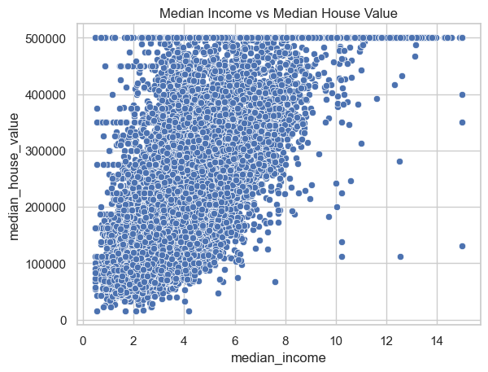

```python
sns.scatterplot(x="median_income", y="median_house_value", data=housing)
plt.title("Median Income vs Median House Value")
plt.show()
```

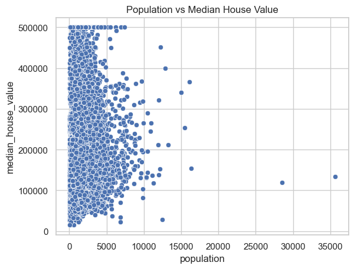

```python
sns.scatterplot(x="population", y="median_house_value", data=housing)
plt.title("Population vs Median House Value")
plt.show()
```

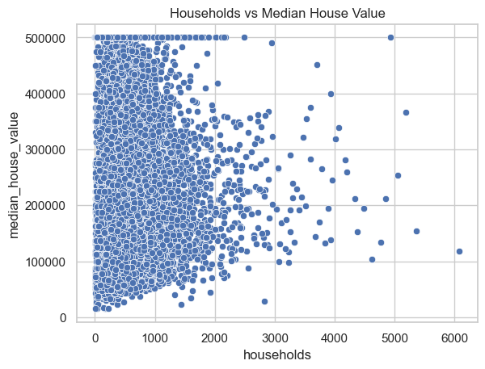

```python
sns.scatterplot(x="households", y="median_house_value", data=housing)
plt.title("Households vs Median House Value")
plt.show()
```

### Data Preprocessing

Filter out records with median_house_value = 500001 since it seems to be a cap for the median_house_value.

```python
housing_preprocessed = housing[housing.median_house_value != 500001]
```

```python
print(f"After filtering, there are {len(housing_preprocessed)} records, versus {len(housing)} before filtering")
```

```
After filtering, there are 19675 records, versus 20640 before filtering
```

### Train and Test Split

Split the data into training/testing sets. Use the first 80% of the data for training.

```python
train_size = int(len(housing_preprocessed) * 0.8)
train = housing_preprocessed[:train_size]
test = housing_preprocessed[train_size:]
```

### Linear Regressions

Creating three linear regression models for each independent variable:

1. median house value vs. median income
2. median house value vs. population
3. median house value vs. number of households

```python
model_income = linear_model.LinearRegression()
model_population = linear_model.LinearRegression()
model_households = linear_model.LinearRegression()
```

#### Train the Model

```python
model_income.fit(X=train[["median_income"]], y=train[["median_house_value"]])
model_population.fit(X=train[["population"]], y=train[["median_house_value"]])
model_households.fit(X=train[["households"]], y=train[["median_house_value"]])
```

```
LinearRegression()
```

#### Model Evaluation

```python
income_mse_train = mean_squared_error(train[["median_house_value"]], model_income.predict(train[["median_income"]]))
income_mae_train = mean_absolute_error(train[["median_house_value"]], model_income.predict(train[["median_income"]]))

pop_mse_train = mean_squared_error(train[["median_house_value"]], model_population.predict(train[["population"]]))
pop_mae_train = mean_absolute_error(train[["median_house_value"]], model_population.predict(train[["population"]]))

households_mse_train = mean_squared_error(train[["median_house_value"]], model_households.predict(train[["households"]]))
households_mae_train = mean_absolute_error(train[["median_house_value"]], model_households.predict(train[["households"]]))

income_mse_test = mean_squared_error(test[["median_house_value"]], model_income.predict(test[["median_income"]]))
income_mae_test = mean_absolute_error(test[["median_house_value"]], model_income.predict(test[["median_income"]]))

pop_mse_test = mean_squared_error(test[["median_house_value"]], model_population.predict(test[["population"]]))
pop_mae_test = mean_absolute_error(test[["median_house_value"]], model_population.predict(test[["population"]]))

households_mse_test = mean_squared_error(test[["median_house_value"]], model_households.predict(test[["households"]]))
households_mae_test = mean_absolute_error(test[["median_house_value"]], model_households.predict(test[["households"]]))


evaluations = pd.DataFrame({
    'Model': ['Median Income', 'Population', 'Households'],
    'Intercept': [model_income.intercept_[0], model_population.intercept_[0], model_households.intercept_[0]],
    'Slope': [model_income.coef_[0][0], model_population.coef_[0][0], model_households.coef_[0][0]],
    'Mean Squared Error TRAIN': [income_mse_train , pop_mse_train, households_mse_train],
    'Mean Absolute Error TRAIN': [income_mae_train, pop_mae_train, households_mae_train],
    'Mean Squared Error TEST': [income_mse_test, pop_mse_test, households_mse_test],
    'Mean Absolute Error TEST': [income_mae_test, pop_mae_test, households_mae_test]
})

evaluations['Intercept'] = evaluations['Intercept'].map('{:.2f}'.format)
evaluations['Slope'] = evaluations['Slope'].map('{:.2f}'.format)
evaluations['Mean Squared Error TRAIN'] = evaluations['Mean Squared Error TRAIN'].map('{:.2f}'.format)
evaluations['Mean Squared Error TEST'] = evaluations['Mean Squared Error TEST'].map('{:.2f}'.format)
evaluations['Mean Absolute Error TRAIN'] = evaluations['Mean Absolute Error TRAIN'].map('{:.2f}'.format)
evaluations['Mean Absolute Error TEST'] = evaluations['Mean Absolute Error TEST'].map('{:.2f}'.format)


display(evaluations.T)
```

|  | 0 | 1 | 2 |
| --- | --- | --- | --- |
| Model | Median Income | Population | Households |
| Intercept | 48204.53 | 188081.59 | 177147.29 |
| Slope | 38702.97 | 0.33 | 22.63 |
| Mean Squared Error TRAIN | 5557954319.26 | 9236185598.97 | 9156895298.29 |
| Mean Absolute Error TRAIN | 55840.00 | 75879.53 | 75463.11 |
| Mean Squared Error TEST | 5831038297.42 | 10863782849.78 | 10759278800.53 |
| Mean Absolute Error TEST | 59961.60 | 85178.91 | 84503.15 |

#### Plotting the regression line

1. Plot the regression line against the training data for median_income model

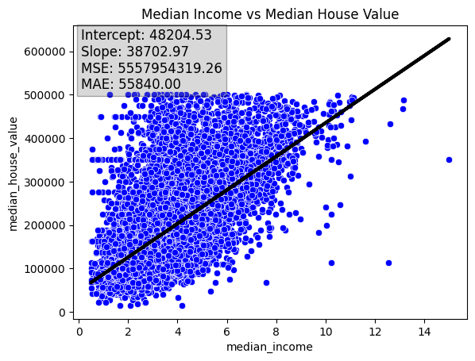

```python
sns.scatterplot(x="median_income", y="median_house_value", data=train, color="blue")
plt.plot(train[["median_income"]], model_income.predict(train[["median_income"]]), color="black", linewidth=3)
textstr = (f'Intercept: {model_income.intercept_[0]:.2f}\n'
           f'Slope: {model_income.coef_[0][0]:.2f}\n'
           f'MSE: {mean_squared_error(train[["median_house_value"]], model_income.predict(train[["median_income"]])):.2f}\n'
           f'MAE: {mean_absolute_error(train[["median_house_value"]], model_income.predict(train[["median_income"]])):.2f}')
props = dict(boxstyle='square', facecolor='grey', alpha=0.3)
plt.text(0.02, 0.99, textstr, transform=plt.gca().transAxes, fontsize=12,
             verticalalignment='top', bbox=props)
plt.title("Median Income vs Median House Value")
plt.show()
```

2. Plot the regression line against the training data for population model

[figure not shown]

```python
sns.scatterplot(x="population", y="median_house_value", data=train, color="blue")
plt.plot(train[["population"]], model_population.predict(train[["population"]]), color="black", linewidth=3)
textstr = (f'Intercept: {model_income.intercept_[0]:.2f}\n'
           f'Slope: {model_income.coef_[0][0]:.2f}\n'
           f'MSE: {mean_squared_error(train[["median_house_value"]], model_population.predict(train[["population"]])):.2f}\n'
           f'MAE: {mean_absolute_error(train[["median_house_value"]], model_population.predict(train[["population"]])):.2f}')
props = dict(boxstyle='square', facecolor='grey', alpha=0.5)
plt.text(0.60, 0.95, textstr, transform=plt.gca().transAxes, fontsize=12,
             verticalalignment='top', bbox=props)
plt.title("Population vs Median House Value")
plt.show()
```

3. Plot the regression line against the training data for households model

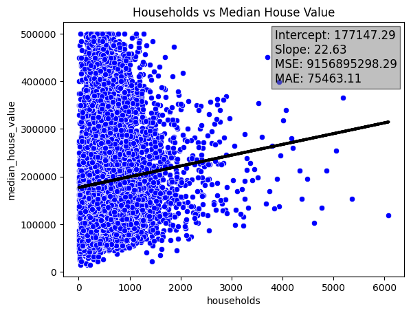

```python
sns.scatterplot(x="households", y="median_house_value", data=train, color="blue")
plt.plot(train[["households"]], model_households.predict(train[["households"]]), color="black", linewidth=3)
textstr = (f'Intercept: {model_households.intercept_[0]:.2f}\n'
           f'Slope: {model_households.coef_[0][0]:.2f}\n'
           f'MSE: {mean_squared_error(train[["median_house_value"]], model_households.predict(train[["households"]])):.2f}\n'
           f'MAE: {mean_absolute_error(train[["median_house_value"]], model_households.predict(train[["households"]])):.2f}')
props = dict(boxstyle='square', facecolor='grey', alpha=0.5)
plt.text(0.62, 0.97, textstr, transform=plt.gca().transAxes, fontsize=12,
             verticalalignment='top', bbox=props)
plt.title("Households vs Median House Value")
plt.show()
```

#### SUMMARY

Following an analysis of each model's performance, the following conclusions can be drawn:

1. We can observe that the median income model works better than the other two models since it has the lowest MSE and MAE, indicating that it is more accurate for the provided dataset.
2. In terms of accuracy, the Households model falls in between the other two models.
3. The population model has the largest MAE and MSE, indicating a lower degree of accuracy in the model.
4. Compared to the other two models, the linear function that is plotted on the median income intercepts more cases.